# Idaho Policy Institute (IPI) Report

- *This copy is not intended to be compiled, some models may become inconsistent with documentation.*

Exploring & Modeling of Municipial Dataset: This is a project presented to my partners and me by our client, The Idaho Policy Institute, In which they provided a dataset containing information on finances, population and crime for virtually every city and/or county in Idaho. The goal of the project was to find relationships between financial decisions with crime and employment trends in cities of Idaho with efferent sizes.

**Notebook Author**

> Dominik Huffield

**Contributors**

> Sammy Bhushan  
> Amir Abbas Kazemzadeh Farizhandi

### Importing libraries

```python
import support.load_data as load
import support.supporting_funcs as funcs
# import support.plotting_funcs as ipiplot

import pandas as pd
import numpy as np
import seaborn as sns
import matplotlib.pyplot as plt
import matplotlib.lines as mlines
from sklearn.model_selection import train_test_split
from sklearn.feature_selection import SelectKBest, chi2
from sklearn.feature_selection import f_regression
from sklearn.linear_model import LassoCV
from linearmodels.panel import PanelOLS
import sympy
from sklearn.metrics import accuracy_score
from sklearn.metrics import r2_score
from sklearn.metrics import mean_squared_log_error
from sklearn.linear_model import BayesianRidge
from sklearn.ensemble import RandomForestRegressor
from statsmodels.stats.outliers_influence import variance_inflation_factor
from statsmodels.tools.tools import add_constant

from sklearn.pipeline import Pipeline
from sklearn.model_selection import GridSearchCV
```

> If local enviorment does not contain any of the modules then the syntax to download through jupyter is  
> `!conda install [package]`  
> or  
> `!pip install [package]`  
> Installation instructions may vary and the official docs should be referenced

## Dataset Classification Manual

Along with the dataset IPI also provided a manual to navigate it's contents, held within this projects repository. This may need to be referenced to understand what some columns are measuring for they are abbreviated however, this notebook should be sufficient in explaining itself.

## Data Sources

We felt this dataset was useful relevant information e.g. employment and business statistics. After importing we merged these tables with the one provided by IPI, or in one case made an additional table. Listed below are all additional sources.

> - U.S. Census Bureau (USC)

>   ```
>     Provides population measurments at various entity levels including state, county and city
>   ```

> - Willamette Government Finance Database (GFD)

>   ```
>     Provides goverment cash flow information for each city/county in Idaho
>   ```

> - Federal Bureau of Investigation (FBI)

>   ```
>     Describes various crime variables
>   ```

> - Bureau of Labor Statistics (BLS)

>   ```
>     Allows for adjustment for inflation and provides employment related statistics
>   ```

## Functions We Created

We created many functions and methods to augment our work such as converting to real dollars using the current year as a parameter. We also did this to regularize some of our variables. Furthermore there are many plotting functions such as heat maps, matricies of distributions and scatter plots, choropleth maps , etc. These methods and functions are all stored within the support folder and have their own documentation. These were hidden for aesthetics and need not be read to understand the process of this notebook.

## Exploring Data

The data given to us by IPI was panel data, Cities or counties being the major axis while the minor axis was indexed by years. There are 200 cities in the set ranging over about 20 years. We clearly had an unbalanced panel for most cities & counties were missing data for serveral years with little consistency amongst themselves. Luckily we were able to identify four years that had data for a decent amount of variables, so we chose to keep those years and remove the rest. This is shown in more depth further down the notebook.  
Along with poor years there were also many cities that contained a small amount of data. We did not incorporate these within our models and the method of removal is shown below. Further more there was not a useful quantity of data at the county level so these variables were removed and the process is stored within a support funtion.  
The financial data was collected in nominal dollars. We used data from BLS to account for inflation and converted these values into real dollars base 2019 so that we would have the best understanding of the value of each dollar. This was done and stored in one of the support functions.

## Objective for Models

The amount of columns contained within the set describing crime amounted to 7 however there were over 500 variables describing financial revenue or expenditure. Using this knowledge we thought it best to attempt to describe crime using financial information as our independent variables (along with additional information). We chose to do this so that we would not limit the features available for our models along with the ability of this type of model to provide a good description of the relation between government finances and crime. The variables describing crime were quantities of occurances so to use this as our dependent variable we needed to construct a regression model.  
A future iteration of this project one might create a classifier that describes whether an increase or decrease in a feature will result in an increase or decease in crime. We do not address this effect of each feature directly to our dependent as to avoid feature phishing.  
**Selecting A Model**  
Since this a panel dataset we wanted to account for the serial correlation resulting from the time series. Additionally we thought a linear model the easiest to interpret and understand the inner workings of the data itself. This lead us to a time effects model for our initial build, however the world is not linear and features will likely contain heteroskedasticity so past comprehension a non-linear approach will likely be a more robust and accurate model.

## Load Dataset

Using one of our functions within the support folder, we will take the dataset and convert the financial values from nominal to real dollars creating a dataframe. We use the CPI for 2019 but future analysis should adjust to the most recent CPI value to allow for full comprehension of a dollar.

```python
df = load.all_data(norm=False)
```

```
Loading IPI data
Adjusting for Inflation
Getting GPS
Getting Employees
Merge Everything
Categorize City Size
```

## Understanding Data Structure

```python
df['Year4'].sort_values().unique()
```

```
array([1995, 1996, 1997, 1998, 1999, 2000, 2001, 2002, 2003, 2004, 2005,
       2006, 2007, 2008, 2009, 2010, 2011, 2012, 2013, 2014])
```

As you can see the range of the time series contains values from 1995 to 2014

```python
df['Name'].unique().size
```

```
200
```

Along the major axis there are 200 different cities

```python
df.set_index(['Name', 'Year4']).loc[('BOISE CITY',np.arange(1995, 2016)), :]
```

| Name | Year4 | County | YearofData | SurveyYr | ID | IDChanged | Type_Code | County | FIPS_Code_State | FIPS_County | FIPS_Place | ... | County/State | County FIPS Year | County Labor Force | County Labor Employed | County Labor Unemployed | Unemployment Rate (%) | postalcode | latitude | longitude | size |
| --- | --- | --- | --- | --- | --- | --- | --- | --- | --- | --- | --- | --- | --- | --- | --- | --- | --- | --- | --- | --- | --- | --- |
| BOISE CITY | 1996 | Ada | 96.0 | 96.0 | 132001001.0 | 0.0 | 2.0 | Ada | 16.0 | 1.0 | 8830.0 | ... | Ada County, ID | 1996.0 | 150733.0 | 145670.0 | 5063.0 | 3.4 | 83701 | 43.6038 | -116.2729 | urban |
|  | 1997 | Ada | 97.0 | 97.0 | 132001001.0 | 0.0 | 2.0 | Ada | 16.0 | 1.0 | 8830.0 | ... | Ada County, ID | 1997.0 | 156552.0 | 151759.0 | 4793.0 | 3.1 | 83701 | 43.6038 | -116.2729 | urban |
|  | 1998 | Ada | 98.0 | 98.0 | 132001001.0 | 0.0 | 2.0 | Ada | 16.0 | 1.0 | 8830.0 | ... | Ada County, ID | 1998.0 | 163205.0 | 157989.0 | 5216.0 | 3.2 | 83701 | 43.6038 | -116.2729 | urban |
|  | 1999 | Ada | 99.0 | 99.0 | 132001001.0 | 0.0 | 2.0 | Ada | 16.0 | 1.0 | 8830.0 | ... | Ada County, ID | 1999.0 | 166095.0 | 160959.0 | 5136.0 | 3.1 | 83701 | 43.6038 | -116.2729 | urban |
|  | 2000 | Ada | 0.0 | 0.0 | 132001001.0 | 0.0 | 2.0 | Ada | 16.0 | 1.0 | 8830.0 | ... | Ada County, ID | 2000.0 | 169932.0 | 164171.0 | 5761.0 | 3.4 | 83701 | 43.6038 | -116.2729 | urban |
|  | 2001 | Ada | NaN | 1.0 | 132001001.0 | 0.0 | 2.0 | Ada | 16.0 | 1.0 | 8830.0 | ... | Ada County, ID | 2001.0 | 175653.0 | 168876.0 | 6777.0 | 3.9 | 83701 | 43.6038 | -116.2729 | urban |
|  | 2002 | Ada | NaN | 2.0 | 132001001.0 | 0.0 | 2.0 | Ada | 16.0 | 1.0 | 8830.0 | ... | Ada County, ID | 2002.0 | 175742.0 | 167437.0 | 8305.0 | 4.7 | 83701 | 43.6038 | -116.2729 | urban |
|  | 2003 | Ada | NaN | 3.0 | 132001001.0 | 0.0 | 2.0 | Ada | 16.0 | 1.0 | 8830.0 | ... | Ada County, ID | 2003.0 | 177056.0 | 168453.0 | 8603.0 | 4.9 | 83701 | 43.6038 | -116.2729 | urban |
|  | 2004 | Ada | NaN | 4.0 | 132001001.0 | 0.0 | 2.0 | Ada | 16.0 | 1.0 | 8830.0 | ... | Ada County, ID | 2004.0 | 178289.0 | 171048.0 | 7241.0 | 4.1 | 83701 | 43.6038 | -116.2729 | urban |
|  | 2005 | Ada | NaN | 5.0 | 132001001.0 | 0.0 | 2.0 | Ada | 16.0 | 1.0 | 8830.0 | ... | Ada County, ID | 2005.0 | 187127.0 | 180914.0 | 6213.0 | 3.3 | 83701 | 43.6038 | -116.2729 | urban |
|  | 2006 | Ada | NaN | 6.0 | 132001001.0 | 0.0 | 2.0 | Ada | 16.0 | 1.0 | 8830.0 | ... | Ada County, ID | 2006.0 | 193828.0 | 188617.0 | 5211.0 | 2.7 | 83701 | 43.6038 | -116.2729 | urban |
|  | 2007 | Ada | NaN | 7.0 | 132001001.0 | NaN | 2.0 | Ada | 16.0 | 1.0 | 8830.0 | ... | Ada County, ID | 2007.0 | 196740.0 | 191500.0 | 5240.0 | 2.7 | 83701 | 43.6038 | -116.2729 | urban |
|  | 2008 | Ada | NaN | 8.0 | 132001001.0 | NaN | 2.0 | Ada | 16.0 | 1.0 | 8830.0 | ... | Ada County, ID | 2008.0 | 196434.0 | 186848.0 | 9586.0 | 4.9 | 83701 | 43.6038 | -116.2729 | urban |
|  | 2009 | Ada | NaN | 9.0 | 132001001.0 | NaN | 2.0 | Ada | 16.0 | 1.0 | 8830.0 | ... | Ada County, ID | 2009.0 | 196383.0 | 178892.0 | 17491.0 | 8.9 | 83701 | 43.6038 | -116.2729 | urban |
|  | 2010 | Ada | NaN | 10.0 | 132001001.0 | NaN | 2.0 | Ada | 16.0 | 1.0 | 8830.0 | ... | Ada County, ID | 2010.0 | 196945.0 | 180585.0 | 16360.0 | 8.3 | 83701 | 43.6038 | -116.2729 | urban |
|  | 2011 | Ada | NaN | 11.0 | 132001001.0 | NaN | 2.0 | Ada | 16.0 | 1.0 | 8830.0 | ... | Ada County, ID | 2011.0 | 200304.0 | 185600.0 | 14704.0 | 7.3 | 83701 | 43.6038 | -116.2729 | urban |
|  | 2012 | Ada | NaN | 12.0 | 132001001.0 | NaN | 2.0 | Ada | 16.0 | 1.0 | 8830.0 | ... | Ada County, ID | 2012.0 | 204353.0 | 191714.0 | 12639.0 | 6.2 | 83701 | 43.6038 | -116.2729 | urban |
|  | 2013 | Ada | NaN | 13.0 | 132001001.0 | NaN | 2.0 | Ada | 16.0 | 1.0 | 8830.0 | ... | Ada County, ID | 2013.0 | 206575.0 | 195843.0 | 10732.0 | 5.2 | 83701 | 43.6038 | -116.2729 | urban |
|  | 2014 | Ada | NaN | 14.0 | 132001001.0 | NaN | 2.0 | Ada | 16.0 | 1.0 | 8830.0 | ... | Ada County, ID | 2014.0 | 211675.0 | 202897.0 | 8778.0 | 4.1 | 83701 | 43.6038 | -116.2729 | urban |

19 rows × 629 columns

Here is a visual representation of one of these cities. Notice that for this city there is not data for 1995 and that we have an unbalaced panel. Some cities are missing many more values than this one and we will address this further down.

```python
df.shape
```

```
(1509, 631)
```

Here you can see that we have over 600 variables

```python
df = df.drop(columns= funcs.search_all(df, 'coun'))
```

```
County
County
FIPS_County
Counties - Assault- Total
Counties - Burglary- Total
Counties - Manslaughter- Total
Counties - Murder- Total
Counties - Rape-Total
Counties - Robbery- Total
Counties - Total- All Thefts
County FIPS Code
County/State
County FIPS Year
County Labor Force
County Labor Employed
County Labor Unemployed
```

Again we reference a supporting function which we use to search for and drop all columns representing county level data. During our exploratory analysis we concluded that there was not enough county level data to be beneficial, cities become our major axis

```python
df.shape
```

```
(1509, 615)
```

After refining the granularity of available variables to only consist of city level data we are left with 615 potential features

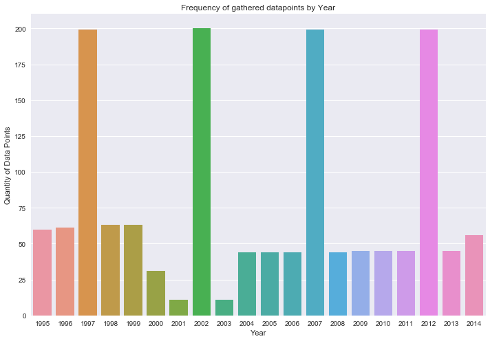

```python
plt.style.use('seaborn')
sns.barplot(x='Year4', y='Population', data=df.groupby('Year4').count().reset_index())
fig = plt.gcf()
fig.set_size_inches(10,7)
plt.ylabel('Quantity of Data Points')
plt.xlabel('Year')
plt.title('Frequency of gathered datapoints by Year')
plt.tight_layout()
```

```python
df = df.loc[df['Year4'].isin([1997, 2002, 2007, 2012])]
```

This plot only shows data points for population but during our analysis we identified that this trend was consistent for most variables. Being an unbalanced panel we removed every year other than 1997, 2002, 2007 and 2012. This provides us measurements on the max number of features while also maintaining balance. Removing these years was necessisary to maintain high quality input data. Notice these years are all evenly spaced so change in variables between years will be clear.

## Selecting a Dependant Variable

As stated under the *"Objective of Model"* section above; the set contains many statistics desribing the financial activity of each city but only seven variables describing crime. These crime statsistics are unique measuements relative to the financial majority. There are a few other columns not describing finances, such as population, but we concluded that these columns would not provide the same value in identifying relations describing criminal activities and goverment financials.

Distinct from crime we also had information on unemployment data and would have liked to use it as the dependent in its own model . We were unable to address this within the time constraint but doing so would likely prove insightful.

```python
df.shape
```

```
(797, 615)
```

After dropping those years from the set we are left with about 800 rows

```python
cities = (df.groupby('Name')['Assault- Total - Municipalities'].count() == 4)
cities = cities[cities == True].index
df = df[df['Name'].isin(cities)]
df.shape
```

```
(236, 615)
```

Having already removed useless data on our minor axis (years) we then sought to do the same to our major axis (cities). Above we removed any city that did not have data for all four years, this reduced the total records in our dataframe to 236. This unfortunately removed a large portion of the original set but greatly improved the overall quality of our scope.

```python
tmp = df.notna().sum()
tmp = tmp[tmp > 206]
df = df.loc[:,tmp.index]
df.shape
```

```
(236, 101)
```

Reducing our set an additional time we removed any feature that did not contain values for at least 87% of the total records. This is the penultimate step in our data purification but will will leave us with 236 records or 59 cities each containing data for 4 years and roughly 100 features.

```python
df = df.set_index(['Name', 'Year4'])
```

We are now done addressing missing data so we set the indices of our dataframe so that it will be recognized as a panel in future manipulations.

```python
df.drop(columns=['LAUS Code', 'latitude', 'longitude'],inplace=True)
```

The column LAUS Code is an object data type and contained little varience so we remnoved it from our set so that we didnt not have to waste time attempting to represent it as quantitative value. Additionally longitude contained negative values that could not be handled in futer models so we chose to remove it along with latitude.

```python
dummies = pd.get_dummies(df['size'])
df.drop(columns=['size'],inplace=True)
df = pd.concat([df, dummies], axis=1)
```

Size is a catagorical variable and depicts the size of a city so we replaced it with three dummy variables representing its three catagories.

## Initial Modeling

Our analyses only addresses Total Thefts as our dependent but with minimal reworking one could construct a loop iterating through each crime statistic as the model's dependent variable.

```python
dep_var = 'Total- All Thefts - Municipalities'
y = df[dep_var]
y = y.rename(dep_var)
y = pd.DataFrame(y)
y = y.astype(int)
```

Here we save Total Thefts as the dependent variable

```python
X = df.drop(columns = ['Robbery- Total - Municipalities',
       'Rape-Total - Municipalities',
       'Murder- Total - Municipalities',
       'Total- All Thefts - Municipalities',
       'Manslaughter-Total - Municipalities',
       'Burglary-Total - Municipalities',
       'Assault- Total - Municipalities'])
```

Now dropping every other crime variable from our data frame as to prevent them from causing undesired noise in our model.

## Interpolation

```python
X = X.interpolate(method='linear')
```

Finally we believe we have derived the optimal set to attempt to describe theft. However there are still a few null values, so we leverage the panel structure and use interpolate to fill in these nulls. Calculating our own values for these nulls is potentially harmful but we minimzed damage done here because we already dropped features that did not contain values for at least 87% of total records. Additionally notice we do not interpolate on the dependent for we do not want to predict predicted values, regardless "y" contained no missing values and we were able to keep the remaining records.

## Split

```python
train_X, val_X, train_y, val_y = train_test_split(X, y, test_size=0.2)
```

We perform a 20 percent test split but after preprocessing our dataset is much smaller, this is not desired but is prefered over noisy input data.

## Lasso

We need to perform feature selection. We want our features to be independent of one another and we want to use SelectKBest to perform a Chi Squared Test however K is a required parameter to do this. We will use a Lasso Regression to identify how many variables we whould use for SelectKBest. This is our initial model so it will be a little bit of a hack job but further down we will construct a pipeline to optimize K and some other hyperparameters.

```python
reg = LassoCV(cv=3, tol=0.009, random_state=201)
reg.fit(train_X, train_y[dep_var])
print("Best alpha using built-in LassoCV: %f" % reg.alpha_)
print("Best score using built-in LassoCV: %f" %reg.score(train_X,train_y))
```

```
Best alpha using built-in LassoCV: 127738.440197
Best score using built-in LassoCV: 0.938150
```

```python
coef = pd.Series(reg.coef_, index = train_X.columns)
k_esi = sum(coef != 0)
print("Lasso picked " + str(k_esi) + " variables")
```

```
Lasso picked 23 variables
```

We will use this value for K in SelectKBest

## SelectKBest

```python
selector = SelectKBest(score_func=chi2, k=k_esi)
selector.fit(train_X, train_y)
```

```
SelectKBest(k=23, score_func=<function chi2 at 0x1a18c344d0>)
```

```python
cols = selector.get_support(indices=True)

X_chi = train_X.iloc[:,cols]
val_X = val_X.iloc[:,cols]
```

We need the features of our model to only contain features that are independent of one another so to achieve this we use SelectKBest to perform a Chi Squared test and then select K values where K is determined by the previous Lasso regression.

## Handling Multicollinearity

```python
reduced_form, inds = sympy.Matrix(X_chi.values).rref()
X_chi = X_chi.iloc[:, list(inds)]
```

Handling linear dependence

```python
# For each X, calculate VIF and save in dataframe
vif = pd.DataFrame()
vif["VIF Factor"] = [variance_inflation_factor(X_chi.values, i) for i in range(X_chi.shape[1])]
vif["features"] = X_chi.columns
```

Leveraging python's *"Variance Inflation Factor"* module to systematically remove collinear variables

```python
indep_var = vif.iloc[vif['VIF Factor'].drop_duplicates().index]['features']
X_chi = X_chi.loc[:,indep_var]
val_X = val_X.loc[:,indep_var]
train_X = X_chi
```

Transforming our train and test dataframes to only contain desired features.

## Time Effects Regression (OLS)

Having cleaned our data we believe OLS to be BLUE so we can now perform our regression

```python
paneols = PanelOLS(train_y[dep_var],X_chi[indep_var], time_effects=True)
res = paneols.fit()
res
```

PanelOLS Estimation Summary

| Dep. Variable: | Total- All Thefts - Municipalities | R-squared: | 0.9564 |
| --- | --- | --- | --- |
| Estimator: | PanelOLS | R-squared (Between): | 0.9824 |
| No. Observations: | 188 | R-squared (Within): | 0.0591 |
| Date: | Sun, Jan 05 2020 | R-squared (Overall): | 0.9611 |
| Time: | 23:14:09 | Log-likelihood | -1344.4 |
| Cov. Estimator: | Unadjusted |  |  |
|  |  | F-statistic: | 190.66 |
| Entities: | 59 | P-value | 0.0000 |
| Avg Obs: | 3.1864 | Distribution: | F(19,165) |
| Min Obs: | 2.0000 |  |  |
| Max Obs: | 4.0000 | F-statistic (robust): | 190.66 |
|  |  | P-value | 0.0000 |
| Time periods: | 4 | Distribution: | F(19,165) |
| Avg Obs: | 47.000 |  |  |
| Min Obs: | 38.000 |  |  |
| Max Obs: | 52.000 |  |  |

Parameter Estimates

|  | Parameter | Std. Err. | T-stat | P-value | Lower CI | Upper CI |
| --- | --- | --- | --- | --- | --- | --- |
| Population | 0.0357 | 0.0072 | 4.9566 | 0.0000 | 0.0215 | 0.0499 |
| Total_Revenue | -0.0063 | 0.0146 | -0.4302 | 0.6676 | -0.0352 | 0.0226 |
| Tot_Chgs_and_Misc_Rev | -0.0559 | 0.0211 | -2.6450 | 0.0090 | -0.0977 | -0.0142 |
| Total_Expenditure | -0.5323 | 0.1851 | -2.8766 | 0.0046 | -0.8977 | -0.1669 |
| Direct_Expenditure | 0.5440 | 0.1804 | 3.0164 | 0.0030 | 0.1879 | 0.9001 |
| Total_Current_Expend | 0.4635 | 0.2000 | 2.3177 | 0.0217 | 0.0686 | 0.8583 |
| Total_Current_Oper | -0.4792 | 0.1980 | -2.4206 | 0.0166 | -0.8700 | -0.0883 |
| General_Expenditure | 0.5076 | 0.2214 | 2.2928 | 0.0231 | 0.0705 | 0.9447 |
| Direct_General_Expend | -0.4201 | 0.2152 | -1.9520 | 0.0526 | -0.8450 | 0.0048 |
| General_Current_Expend | -0.0859 | 0.1486 | -0.5780 | 0.5640 | -0.3793 | 0.2075 |
| General_Current_Oper | 0.0475 | 0.1458 | 0.3260 | 0.7448 | -0.2403 | 0.3354 |
| Total_Debt_Outstanding | 0.0639 | 0.2671 | 0.2391 | 0.8113 | -0.4636 | 0.5913 |
| Total_Long_Term_Debt_Out | 1.0086 | 1.1462 | 0.8799 | 0.3802 | -1.2545 | 3.2718 |
| Total_Beg_LTD_Out | -1.6164 | 0.9735 | -1.6603 | 0.0987 | -3.5386 | 0.3058 |
| Beg_LTD_Out_All_Other | 1.6591 | 0.9768 | 1.6985 | 0.0913 | -0.2696 | 3.5877 |
| LTD_Out_All_Other | -1.1319 | 1.1263 | -1.0049 | 0.3164 | -3.3558 | 1.0920 |
| Total_Cash___Securities | -0.0788 | 0.0231 | -3.4163 | 0.0008 | -0.1244 | -0.0333 |
| Nonin_Trust_Cash___Sec | 0.0959 | 0.0312 | 3.0764 | 0.0025 | 0.0343 | 0.1574 |
| Oth_Nonin_Fd_Cash___Sec | -0.0289 | 0.0141 | -2.0450 | 0.0424 | -0.0569 | -0.0010 |

F-test for Poolability: 3.2885  
P-value: 0.0222  
Distribution: F(3,165)  
Included effects: Time  
id: 0x1a221fd490

This model appears to be a good representation of the data. From this we can see that Population, Total_Cash**Securities, Nonin_Trust_Cash**Sec, Total_Expenditure, ect. all are largly statistically significant in identifying Total Theft  
Population and Total Expenditure seem to be accurate in describing Total Theft with low standard errors. This makes logical sense in that the more people in an area the more crime. Oth_Nonin_Fd_Cash**Sec, Tot_Chgs_and_Misc_Rev and Nonin_Trust*Cash***Sec also have low std. errors.  
Our final P-value appears to be statistically significant so lets use our test data to see how it performs with unseen data.

```python
pred_y_pane = res.predict(val_X)
r2_score(val_y, pred_y_pane)
```

```
0.8002796399457671
```

The R squared using unseen data.  
Our R square dropped a bit but it still appears to be decent. We will make some improvements further down.

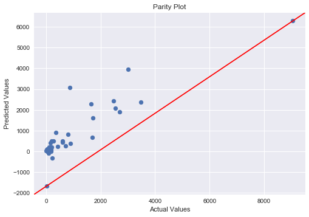

```python
fig, ax = plt.subplots()

ax.scatter(x=val_y, y=pred_y_pane['predictions'])
line = mlines.Line2D([0,1], [0,1], color='red')
transform = ax.transAxes
line.set_transform(transform)
ax.add_line(line)
ax.set_title('Parity Plot')
ax.set_xlabel('Actual Values')
ax.set_ylabel('Predicted Values')
plt.show()
```

Above is a parity plot simply to give a visual representation of how our model is predicting. From it you can see that the model is optimistically biased and predicting high.

## Scatter Plots of Dependent against Independent variables

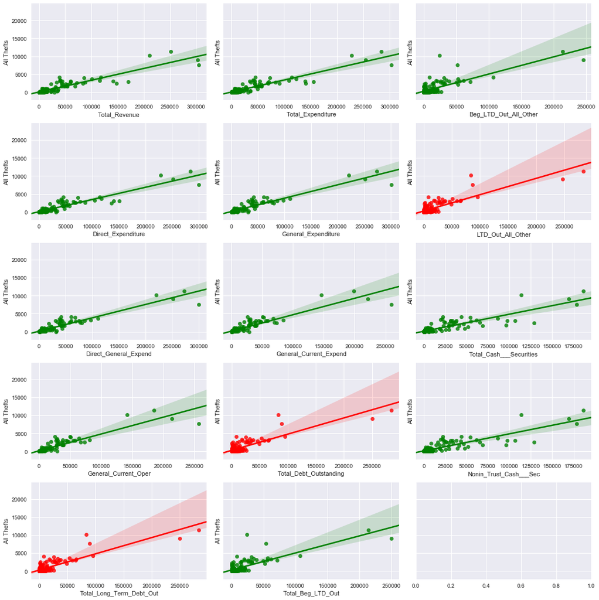

```python
fig1, axs= plt.subplots(figsize=(15,15),nrows=5, ncols=3, sharey=True)


sns.regplot(y=y['Total- All Thefts - Municipalities'], x=X['Total_Revenue'], ax=axs[0,0], color='g')
axs[0, 0].set_xlabel("Total_Revenue")
axs[0, 0].set_ylabel('All Thefts')


sns.regplot(y=y['Total- All Thefts - Municipalities'], x=X['Total_Expenditure'], ax=axs[0,1], color='g')
axs[0, 1].set_xlabel("Total_Expenditure")
axs[0, 1].set_ylabel('All Thefts')


sns.regplot(y=y['Total- All Thefts - Municipalities'], x=X['Beg_LTD_Out_All_Other'], ax=axs[0,2], color='g')
axs[0, 2].set_xlabel("Beg_LTD_Out_All_Other")
axs[0, 2].set_ylabel('All Thefts')

###############

sns.regplot(y=y['Total- All Thefts - Municipalities'], x=X['Direct_Expenditure'], ax=axs[1,0], color='g')
axs[1, 0].set_xlabel("Direct_Expenditure")
axs[1, 0].set_ylabel('All Thefts')

sns.regplot(y=y['Total- All Thefts - Municipalities'], x=X['General_Expenditure'], ax=axs[1,1], color='g')
axs[1, 1].set_xlabel("General_Expenditure")
axs[1, 1].set_ylabel('All Thefts')


sns.regplot(y=y['Total- All Thefts - Municipalities'], x=X['LTD_Out_All_Other'], ax=axs[1,2], color='r')
axs[1, 2].set_xlabel("LTD_Out_All_Other")
axs[1, 2].set_ylabel('All Thefts')
##################

sns.regplot(y=y['Total- All Thefts - Municipalities'], x=X['Direct_General_Expend'], ax=axs[2,0], color='g')
axs[2, 0].set_xlabel("Direct_General_Expend")
axs[2, 0].set_ylabel('All Thefts')

sns.regplot(y=y['Total- All Thefts - Municipalities'], x=X['General_Current_Expend'], ax=axs[2,1], color='g')
axs[2, 1].set_xlabel("General_Current_Expend")
axs[2, 1].set_ylabel('All Thefts')


sns.regplot(y=y['Total- All Thefts - Municipalities'], x=X['Total_Cash___Securities'], ax=axs[2,2], color='g')
axs[2, 2].set_xlabel("Total_Cash___Securities")
axs[2, 2].set_ylabel('All Thefts')
###############

sns.regplot(y=y['Total- All Thefts - Municipalities'], x=X['General_Current_Oper'], ax=axs[3,0], color='g')
axs[3, 0].set_xlabel("General_Current_Oper")
axs[3, 0].set_ylabel('All Thefts')

sns.regplot(y=y['Total- All Thefts - Municipalities'], x=X['Total_Debt_Outstanding'], ax=axs[3,1], color='r')
axs[3, 1].set_xlabel("Total_Debt_Outstanding")
axs[3, 1].set_ylabel('All Thefts')


sns.regplot(y=y['Total- All Thefts - Municipalities'], x=X['Nonin_Trust_Cash___Sec'], ax=axs[3,2], color='g')
axs[3, 2].set_xlabel("Nonin_Trust_Cash___Sec")
axs[3, 2].set_ylabel('All Thefts')
##################

sns.regplot(y=y['Total- All Thefts - Municipalities'], x=X['Total_Long_Term_Debt_Out'], ax=axs[4,0], color='r')
axs[4, 0].set_xlabel("Total_Long_Term_Debt_Out")
axs[4, 0].set_ylabel('All Thefts')

sns.regplot(y=y['Total- All Thefts - Municipalities'], x=X['Total_Beg_LTD_Out'], ax=axs[4,1], color='g')
axs[4, 1].set_xlabel("Total_Beg_LTD_Out")
axs[4, 1].set_ylabel('All Thefts')



plt.tight_layout()
```

Taking a few of the independent varibles and ploting them against the dependent there arises some heteroskedasticity, as shown above, so a non-linear estimator will likely produce the best model. One might perform an F-test for validation but lets run with this.

## Bayesian Ridge Regression

```python
clf = BayesianRidge(compute_score=True)
clf.fit(train_X, train_y)
pred_y_baye = clf.predict(val_X)
```

```python
r2_score(val_y, pred_y_baye)
```

```
0.9200199035858511
```

The R squared using unseen data  
Compared to our time effects model this provided a pretty decent prediction

## Random Forest

```python
regr = RandomForestRegressor(n_estimators=100, random_state=201)
regr.fit(train_X, train_y)
pred_y_rand = regr.predict(val_X)
```

```python
r2_score(val_y, pred_y_rand)
```

```
0.8876877839968651
```

The R squared using unseen data  
Slightly lower than the ridge model but being a random model we should attempt to optimize the parameter n_estimators.

```python
np.sqrt(mean_squared_log_error(val_y, pred_y_rand))
```

```
0.49496668350171347
```

## Optimizing HyperParameters with GridSearchCV

```python
train_X, val_X, train_y, val_y = train_test_split(X, y, test_size=0.2)
```

We will redo the split because we altered the training data during the Chi Squared test earlier

```python
tuned_params = [{'kbest__k':np.arange(5,X.columns.size//2, 5), 'rand__n_estimators':[5,10,50,100,500,1000]}]
model = SelectKBest(score_func=chi2, k=2)

pipeline = Pipeline([('kbest',model), ('rand', RandomForestRegressor(n_estimators=5, random_state=201))])

clf = GridSearchCV(estimator=pipeline, param_grid=tuned_params, cv=5, refit=True, scoring='neg_mean_squared_error')

clf.fit(train_X, train_y[dep_var])
```

```
GridSearchCV(cv=5, error_score='raise-deprecating',
             estimator=Pipeline(memory=None,
                                steps=[('kbest',
                                        SelectKBest(k=2,
                                                    score_func=<function chi2 at 0x1a18c344d0>)),
                                       ('rand',
                                        RandomForestRegressor(bootstrap=True,
                                                              criterion='mse',
                                                              max_depth=None,
                                                              max_features='auto',
                                                              max_leaf_nodes=None,
                                                              min_impurity_decrease=0.0,
                                                              min_impurity_split=None,
                                                              min_samples_leaf=1,
                                                              min_sample...
                                                              min_weight_fraction_leaf=0.0,
                                                              n_estimators=5,
                                                              n_jobs=None,
                                                              oob_score=False,
                                                              random_state=201,
                                                              verbose=0,
                                                              warm_start=False))],
                                verbose=False),
             iid='warn', n_jobs=None,
             param_grid=[{'kbest__k': array([ 5, 10, 15, 20, 25, 30, 35, 40]),
                          'rand__n_estimators': [5, 10, 50, 100, 500, 1000]}],
             pre_dispatch='2*n_jobs', refit=True, return_train_score=False,
             scoring='neg_mean_squared_error', verbose=0)
```

Using a pipeline with SelectKBest, RandomForest and GridSearchCV we optimized K of SelectKBest and the number of estimators (n) of RandomForest. We used GridSearchCV which is rather exhaustive but could likely become more efficient if replaced by RandomSearch

```python
clf.best_params_
```

```
{'kbest__k': 40, 'rand__n_estimators': 50}
```

The optimal values according to our pipeline

```python
pred_y_grid = clf.predict(val_X)
r2_score(val_y, pred_y_grid)
```

```
0.9283603721744912
```

The R squared using unseen data  
This provided us with the best model, furthermore this pipeline could easily be isolated with the preprocessing steps and turned into a pickle for further use.

```python
np.sqrt(mean_squared_log_error(val_y, pred_y_grid))
```

```
0.8737374807124313
```

## Potential Future Steps

From this analysis we have provided a linear model estimating total theft of Idaho cities. Furthermore we constructed a pipeline that produces a more robust model. For further iterations of the project there are serveral places of potential improvement.

> - Feature engineering & importing relevent data.
> - Perform a better imputation technique.
> - Perform further test to determine optimal features.
> - Replace GridSearch with RandomSearch or some other better method to optimize hyper parameters.
> - Improve models by using a more effective algorithm or better yet applying deep learning techniques.
> - Package everything into a pickle
> - Construct models for the other variables measuring crime